# R 實作：Bootstrap、相關與簡單線性迴歸

Week 06 Part 1｜R 實習 3

HT3001B 生物統計學與 R

2026-10-15

## 用 R 做一次有放回重抽

```r
x <- c(9.1, 10.4, 11.8, 8.7,
       14.2, 10.9, 12.5, 9.8,
       23.0, 10.1, 11.2, 9.5)
n <- length(x)
mean(x)  # 11.76667

set.seed(73)
boot_one <- sample(
  x, size = n, replace = TRUE)
boot_one
mean(boot_one)  # 10.26667
```

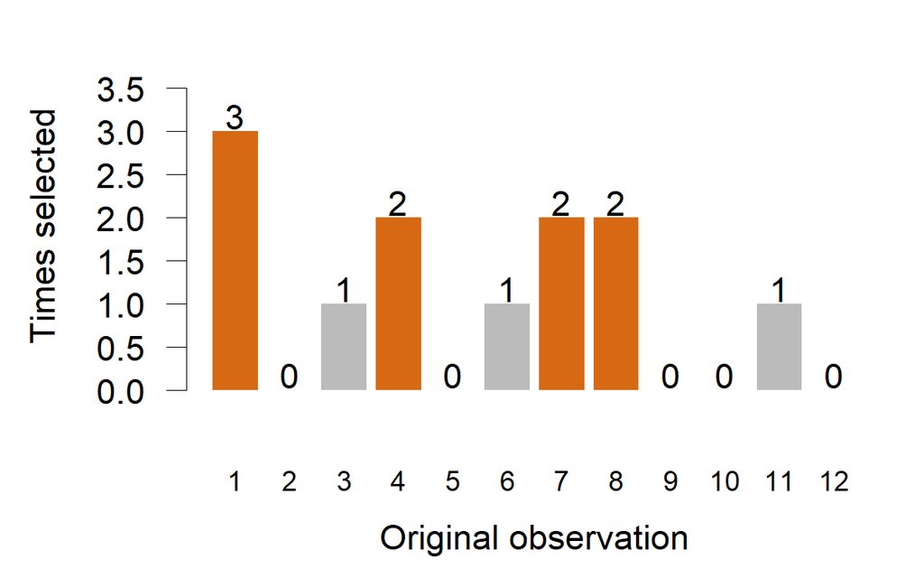

橫軸是原始觀察編號，縱軸是這次被抽到的次數；合計仍為 12 筆。

- 自助重抽樣（bootstrap）：每份抽回 **n 筆**，允許重複，也可能漏掉某些原始觀察。
- `set.seed()` 固定亂數起點，方便重現結果。

Week 05 Part 2 自編 12 筆示範資料；IMS 2e §12.1.2；本次 R 實作與自製圖，seed=73

## replicate()：每次重抽，再算一次平均

```r
set.seed(1008)
B <- 10000
boot_means <- replicate(
  B,
  mean(sample(x, size = n,
              replace = TRUE))
)

length(boot_means)  # 10000
head(boot_means)
```

- `replicate(B, 運算式)` 重新執行運算式 B 次，收集每次的結果。

| 數量 | 代表什麼？ |
| --- | --- |
| `n = 12` | 每份重抽樣本的筆數 |
| `B = 10000` | 重抽樣本的份數 |
| `boot_means` | 10,000 個平均數 |

- **sample() 要放在 replicate() 裡面**，每次才會重新抽。

Week 05 Part 2「重複 B 次」；IMS 2e §12.1.2；本次各統計量獨立設定 seed=1008

## 原始值的散布，與平均數的變動

```r
hist(boot_means, breaks = 30,
     col = "grey80",
     main = "Bootstrap means",
     xlab = "Resampled mean")
abline(v = mean(x),
       col = "darkorange", lwd = 2)

sd(x)           # 3.860
sd(boot_means)  # 1.061
```

- 直方圖（histogram）每個值來自**一份重抽樣本的平均**；橫軸不是原始觀察值。
- `sd(x)` 描述 12 個原始值的散布。
- `sd(boot_means)` 是 bootstrap 標準誤（standard error，SE），估計平均數的抽樣變動。
- 增加 B 讓模擬更穩定；**原始資料仍只有 12 筆**。

IMS 2e §12.1.2、§19.1.3；Week 05 bootstrap 分布與 SE；本次 R 4.4.3 實跑

## 用百分位數取得 95% 信賴區間

```r
boot_se <- sd(boot_means)
boot_ci <- quantile(
  boot_means,
  probs = c(0.025, 0.975)
)

round(boot_se, 3)
# 1.061
round(boot_ci, 2)
# 10.08  14.09
```

- 兩端各留 2.5%，中間留下 95% 的 bootstrap 平均數。

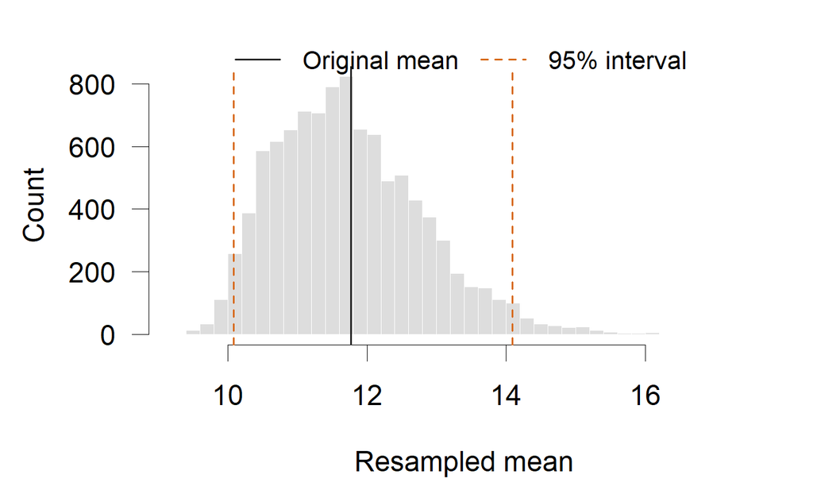

黑線是原始樣本平均；橘色虛線是重抽平均的第 2.5 與 97.5 百分位數。

- 這是**母體平均數**的百分位信賴區間（percentile confidence interval），不是個別觀察值的範圍。
- 12 筆自編資料只示範步驟；小樣本或抽樣偏差可能讓區間不可靠。

Week 05 Part 2 百分位法；IMS 2e §12.3.2、§19.1.5；自製圖，B=10,000，seed=1008

## 換成中位數，重抽步驟相同

```r
set.seed(1008)
boot_medians <- replicate(
  B,
  median(sample(x, size = n,
                replace = TRUE))
)
median(x)  # 10.65
quantile(boot_medians,
         probs = c(0.025, 0.975))
# 9.65  12.15
```

- 把每次的 `mean()` 改為 `median()`，就得到**中位數的 bootstrap 分布**。
- `sd(boot_medians)` 估計中位數的 SE。
- 區間 (9.65, 12.15) 估計的是母體中位數；前頁估計母體平均數，兩者回答的問題不同。
- 一般 bootstrap 需要樣本能代表目標母體，觀察值彼此獨立；重抽無法補救抽樣偏差。

Week 05 Part 2 中位數 bootstrap；IMS 2e §12.1.2、§19.1.5；本次 R 實跑

## 練習｜不放回抽完 12 筆，平均會變嗎？

```r
wrong <- replicate(
  B, mean(sample(x, size = n, replace = FALSE))
)
sd(wrong)
```

- 這段程式每次抽完原樣本的 12 筆。它能估計平均數的 SE 嗎？要改哪一個引數？
- 每次只把同一組數值重新排序，平均數都相同，因此 `sd(wrong)` 為 0（或電腦計算的極小誤差）。
- 把 `replace = FALSE` 改成 **`replace = TRUE`**，每個值的抽中次數才可能改變。

本課程自編 R 邏輯練習；概念對照 Week 05 Part 2、IMS 2e §12.1.2

## 同一份資料，兩種問題

| 欄位 | 意義 | 單位 |
| --- | --- | --- |
| `mage` | 母親年齡 | 歲 |
| `fage` | 父親年齡 | 歲 |
| `weeks` | 懷孕週數 | 週 |
| `weight` | 出生體重 | 磅（lb） |

- `births14`：美國 2014 年出生紀錄抽出 1,000 筆，一列一筆出生。
- **問題 A**：母親與父親年齡是否一起變動？
- 兩者地位對等 → **相關（correlation）**
- **問題 B**：知道懷孕週數，平均出生體重預測多少？
- 體重是結果、週數是解釋 → **迴歸（regression）**

[openintro births14](https://openintrostat.github.io/openintro/reference/births14.html)；IMS 2e §24.2 使用同一份資料

## 每一步，補上哪個答案？

| 步驟 | 要回答的問題 |
| --- | --- |
| 先說問題 | 想描述關聯，還是預測平均？ |
| 確認資料列 | 這個數字使用哪些紀錄？ |
| 畫散布圖 | 形狀適合哪一種摘要？ |
| 計算與核對 | r、斜率與 R² 如何對應？ |
| 看殘差 | 一條線還留下什麼問題？ |
| 寫結論 | 能說到哪裡？還有何限制？ |

- 把問題、程式、圖與結論留在同一份 Quarto，分析才有可追溯的路徑。

本課程自編分析流程；births14

## 建立本週的 Quarto 檔

````markdown
---
title: "Week 06 R 實習"
format:
  html:
    embed-resources: true
---

```{r}
#| label: setup
#| message: false
library(openintro)
library(dplyr)
library(ggplot2)
library(readr)
```
````

1. 上傳 `week06_lab_starter.qmd` 到 Project 根目錄。
2. 另存為 `week06_lab.qmd`。
3. 先在檔內寫下兩個問題的暫答。
- Render 從第一塊重新執行，也檢查分析是否完整。只在 Console 建立的物件，沒有留在檔案的產生路徑。

[Quarto：在 RStudio 使用](https://quarto.org/docs/get-started/hello/rstudio.html)；第 6 週起作業以 QMD 繳交

## 載入資料，先數遺漏

```r
data("births14",
     package = "openintro")
dat <- births14

dat |>
  summarise(
    n_rows = n(),
    fage_missing = sum(is.na(fage)),
    weeks_missing = sum(is.na(weeks)),
    weight_missing = sum(is.na(weight))
  )
```

| 項目 | 筆數 |
| --- | --- |
| 總列數 | 1,000 |
| `fage` 遺漏 | 114 |
| `mage`、`weeks`、`weight` 遺漏 | 0 |

- 問題 A 最多 886 筆，問題 B 可用 1,000 筆。
- 各問題分開交代**分析筆數**。問題 B 不用父親年齡，不必因它遺漏便排除。完整資料分析（complete-case analysis）仍可能有遺漏偏差。

openintro 2.5.1 實跑結果

## 套用到 births14：平均出生體重的區間

```r
w <- dat$weight[!is.na(dat$weight)]
set.seed(1008)
boot_weight <- replicate(
  B,
  mean(sample(w, size = length(w),
              replace = TRUE))
)
mean(w)          # 7.198 磅
sd(boot_weight)  # 0.0418 磅
quantile(boot_weight,
         probs = c(0.025, 0.975))
# 7.114  7.279 磅
```

- 先排除體重遺漏值，再固定樣本大小；本資料 `length(w) = 1000`。
- 平均體重約 **7.20 磅**，百分位 95% CI 約 **(7.11, 7.28) 磅**。
- 這裡把每列出生紀錄視為獨立、具代表性的觀察。區間描述母體平均體重的不確定性，不能推成「95% 新生兒體重都在這裡」。

openintro births14；Week 05 方法的自編應用；R 4.4.3，n=1,000、B=10,000、seed=1008

## 建立分析資料，畫散布圖

```r
ages <- dat |>
  filter(!is.na(mage), !is.na(fage))
nrow(ages)   # 886

ggplot(ages,
       aes(x = mage, y = fage)) +
  geom_point(alpha = 0.4) +
  labs(x = "Mother's age (years)",
       y = "Father's age (years)") +
  theme_minimal()
```

| 設定 | 作用 |
| --- | --- |
| `filter(!is.na())` | 只留兩個年齡都有值的列 |
| `geom_point()` | 散布圖（scatterplot），一點一筆 |
| `alpha = 0.4` | 半透明，疊越多顏色越深 |

- 同一筆出生的兩個年齡要一起保留；分別刪除兩欄的 NA，可能造成錯配。

[ggplot2 geom_point](https://ggplot2.tidyverse.org/reference/geom_point.html)；births14

## 讀散布圖：先看四件事

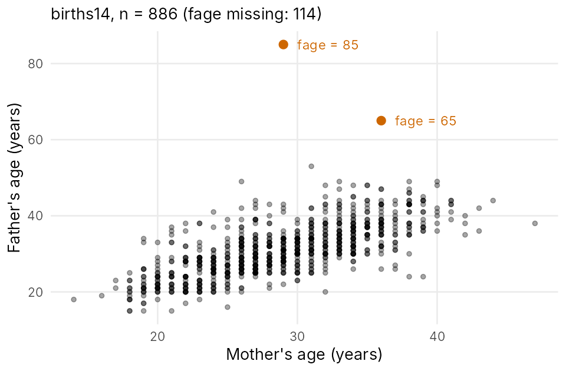

橫軸母親年齡、縱軸父親年齡；橘點標出父親 85、65 歲的紀錄。

- 正向、大致線性、中等偏強，有兩個極端點。先看形狀，才知道接下來的線性摘要是否有用。

births14，n = 886；自製圖，橘色標示為講義加註

## 找出極端點，先不刪

```r
ages |>
  filter(fage >= 60) |>
  select(mage, fage, weeks, weight)
```

| mage | fage | weeks | weight |
| --- | --- | --- | --- |
| 29 | 85 | 35 | 5.95 |
| 36 | 65 | 36 | 4.54 |

- 資料無法告訴我們這是登錄錯誤還是真實情況。
- 先保留、標記，再比較有／無該點的結果。「有影響」與「有理由刪除」是兩個問題。

births14 實跑結果

## cor()：兩種相關係數

```r
cor(ages$mage, ages$fage)
cor(ages$fage, ages$mage)

cor(ages$mage, ages$fage,
    method = "spearman")
```

| 程式 | 結果 |
| --- | --- |
| 第 1 行 | 0.694 |
| 第 2 行（對調） | 0.694 |
| Spearman | 0.728 |

- Pearson 相關係數（Pearson correlation coefficient，r）有正負方向；交換 x、y 時數值不變。
- Spearman 等級相關（Spearman rank correlation）先換成等級，保留大小次序。選哪個，取決於要描述什麼。

[R cor](https://stat.ethz.ch/R-manual/R-devel/library/stats/html/cor.html)；births14，n = 886

## 遺漏值：use 而不是 na.rm

```r
cor(dat$mage, dat$fage)

cor(dat$mage, dat$fage,
    use = "complete.obs")

cor(dat$mage, dat$fage,
    na.rm = TRUE)
```

| 程式 | 結果 |
| --- | --- |
| 第 1 行 | `NA` |
| 第 2 行 | 0.694 |
| 第 3 行 | 錯誤：unused argument |

- `use = "complete.obs"` 保留完整配對，與前面建立 `ages` 的結果相同。
- `cor()` 沒有 `na.rm` 引數。

[R cor](https://stat.ethz.ch/R-manual/R-devel/library/stats/html/cor.html)；births14 實跑結果

## 練習 1｜換單位，還是反轉次序？

```r
cor(ages$mage, ages$fage * 12)
cor(ages$mage, -ages$fage)
```

- 先預測正負與大小，再執行核對。
- 第一行改用月；第二行只是反轉數值次序的示例。
- 第一行 **0.694**：乘正數，次序不變。
- 第二行 **−0.694**：只反轉一個變項，正負號改變，強度不變。
- Week 7 Part 1 會用 z 分數解釋。

births14；本課程自編練習；IMS 2e §7.1.4

## cor.test()：讀估計值與區間

```r
cor.test(~ mage + fage,
         data = ages)
```

```
95 percent confidence interval:
 0.6586849 0.7270323
sample estimates:
      cor
0.6944216
```

| 輸出 | 意思 |
| --- | --- |
| `sample estimates` | r = 0.694 |
| `95 percent confidence interval` | (0.659, 0.727) |

- r 描述這批配對；CI 評估換一批樣本時的估計變動。長期涵蓋率讀法沿用 Week 05，仍依賴抽樣與方法條件。
- `t`、`df`、`p-value` 第 7 週再讀。

[R cor.test](https://stat.ethz.ch/R-manual/R-devel/library/stats/html/cor.test.html)；births14，n = 886

## Spearman 版本與同分值

```r
cor.test(~ mage + fage,
         data = ages,
         method = "spearman",
         exact = FALSE)
```

```
sample estimates:
      rho
0.7282738
```

- 年齡有大量同分值。不加 `exact = FALSE` 會出現警告：
- `Cannot compute exact p-value with ties`
- 警告只和 p 值的算法有關，`rho` 不受影響。
- R 的 Spearman 版本不給信賴區間。

[R cor.test](https://stat.ethz.ch/R-manual/R-devel/library/stats/html/cor.test.html)；births14 實跑結果

## 敏感度比較：暫時排除一筆

```r
ages |>
  filter(fage != 85) |>
  summarise(
    n = n(),
    pearson = cor(mage, fage),
    spearman = cor(mage, fage,
                   method = "spearman")
  )
```

|  | n | Pearson | Spearman |
| --- | --- | --- | --- |
| 全部 | 886 | 0.694 | 0.728 |
| 排除 85 | 885 | 0.718 | 0.729 |

- 原始資料不動，兩結果**並列報告**。r 變大不證明排除更正確；敏感度比較也未證明登錄錯誤。

births14 實跑結果；IMS 2e §7.3 建議有／無該點的兩次分析

## 練習 2｜為什麼 Pearson 變大？

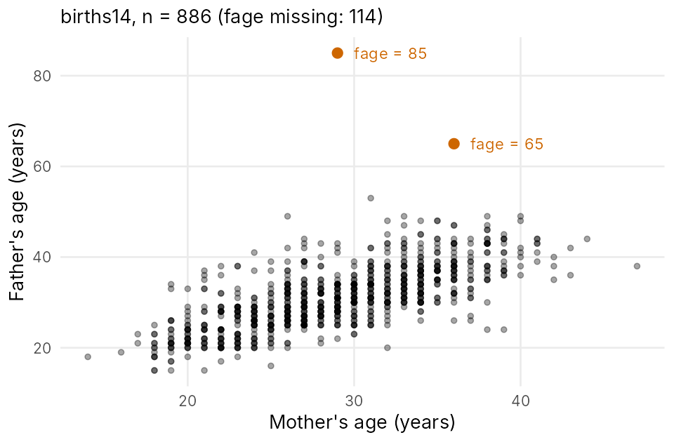

觀察橘色 85 歲那一點，是否沿著多數點的右上趨勢。

- 排除 fage = 85 後，Pearson 由 0.694 升為 0.718。為什麼是變大？
- 這一點母親 29 歲（接近平均），父親卻遠高於平均，偏離右上的趨勢，拉低了線性關聯。
- 在這份資料中，Spearman 由 0.728 變 0.729；這不表示它永遠不受極端點影響。

births14；本課程自編練習

## 從關聯轉向預測：問題 B

```r
bw <- dat |>
  filter(!is.na(weeks),
         !is.na(weight))
range(bw$weeks)   # 21 46

set.seed(1015)
ggplot(bw, aes(x = weeks,
               y = weight)) +
  geom_jitter(width = 0.2,
              height = 0, alpha = 0.3) +
  geom_smooth(method = "lm",
              formula = y ~ x, se = FALSE)
```

| 設定 | 作用 |
| --- | --- |
| `geom_jitter()` | 畫圖時把點左右移動 |
| `height = 0` | 體重不動 |
| `set.seed()` | 每次抖動位置相同 |
| `method = "lm"` | 疊上最小平方線 |

- 改問平均體重，就需要有方向、有單位的模型。抖動只顯示重疊，沒有增加樣本或週數精度。

[geom_jitter](https://ggplot2.tidyverse.org/reference/geom_jitter.html)／[geom_smooth](https://ggplot2.tidyverse.org/reference/geom_smooth.html)；births14

## 懷孕週數與出生體重

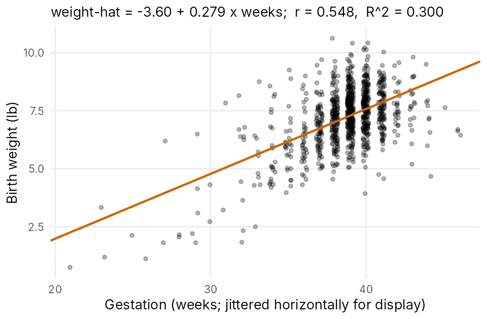

橫軸懷孕週數、縱軸出生體重；橘線為平均體重的線性預測。

- 大多數點在 37–42 週。資料範圍內各區段的密度不同，預測支持也不相同；接著用殘差檢查。

births14，n = 1,000；自製圖

## lm()：配適一條直線

```r
fit <- lm(weight ~ weeks,
          data = bw)
coef(fit)
```

```
(Intercept)       weeks
 -3.5979701   0.2792151
```

- `y ~ x`：波浪號左邊是結果變項。
- 預測體重 = −3.598 + 0.279 × 週數

| 係數 | 解讀 |
| --- | --- |
| 斜率（slope） 0.279 磅／週 | 直線模型中，週數多一週，預測平均體重多 0.28 磅 |
| 截距（intercept） −3.598 磅 | 0 週遠在資料外，沒有實際意義 |

[R lm](https://stat.ethz.ch/R-manual/R-devel/library/stats/html/lm.html)；births14 實跑結果

## summary()：先讀係數與 R²

```
            Estimate Std. Error t value Pr(>|t|)
(Intercept) -3.59797    0.52273  -6.883 1.03e-11 ***
weeks        0.27922    0.01349  20.699  < 2e-16 ***
Residual standard error: 1.094 on 998 degrees of freedom
Multiple R-squared:  0.3004,    Adjusted R-squared:  0.2997
```

| 讀 | 意思 |
| --- | --- |
| `Estimate` | b₀、b₁ |
| `Multiple R-squared` | R² = 0.300 |

- `t value`、`Pr(>|t|)`、星號：第 7 週。`Adjusted R-squared`：第 11 週。

`summary(fit)` 節錄；births14 實跑結果

## 核對：斜率與 R² 從哪裡來

```r
bw |>
  summarise(
    r = cor(weeks, weight),
    s_x = sd(weeks),
    s_y = sd(weight),
    b1 = r * s_y / s_x,
    b0 = mean(weight) - b1 * mean(weeks)
  )

cor(bw$weeks, bw$weight)^2
```

| r | s_x | s_y | b₁ | b₀ |
| --- | --- | --- | --- | --- |
| 0.548 | 2.56 | 1.31 | 0.279 | −3.60 |

- $b_1 = r \cdot s_y / s_x$，與 `lm()` 相同：兩條計算路徑吻合，還不代表模型前提成立。
- $r^2 = 0.548^2 = 0.300$ = R²。此處是含截距、同一批資料的單一解釋變項最小平方迴歸。

births14 實跑結果；公式見 IMS 2e §7.2.3、§7.2.5

## 殘差：觀察值減預測值

```r
bw_fit <- bw |>
  mutate(
    fitted = fitted(fit),
    resid = resid(fit)
  )

bw_fit |>
  select(weeks, weight,
         fitted, resid) |>
  head(3)
```

| weeks | weight | fitted | resid |
| --- | --- | --- | --- |
| 37 | 6.96 | 6.73 | 0.23 |
| 41 | 8.86 | 7.85 | 1.01 |
| 37 | 7.51 | 6.73 | 0.78 |

- 殘差（residual）e = y − ŷ。正值：實際比預測重。
- `bw` 已排除遺漏；加入向量時還要保持配適時的列順序。

births14 實跑結果

## 練習 3｜用另一條計算路徑核對 R²

```r
sst <- sum((bw$weight -
            mean(bw$weight))^2)
sse <- sum(resid(fit)^2)
1 - sse / sst
summary(fit)$r.squared
```

- `resid(fit)` 取出觀察值減預測值。基準只預測平均體重，兩行應相同嗎？
- **都約 0.300。**
- 總平方和（total sum of squares，SST）約 1706；殘差平方和（sum of squared residuals，SSE）約 1194。
- 比起只預測平均數，這條線在同一批資料的**平方誤差和**減少約 30%。
- 這是整批資料的改善，還沒看出誤差落在哪裡。下一步看殘差圖；不能讀成 30% 新生兒預測正確。

births14 本機 R 重算；本課程自編練習；IMS 2e §7.2.5

## 畫殘差圖

```r
ggplot(bw_fit,
       aes(x = fitted, y = resid)) +
  geom_point(alpha = 0.3) +
  geom_hline(yintercept = 0,
             linetype = "dashed") +
  labs(x = "Fitted birth weight (lb)",
       y = "Residual (lb)") +
  theme_minimal()
```

- 殘差圖（residual plot）：橫軸預測值，縱軸殘差。
- 扣掉直線已描述的趨勢，以 0 為共同基準，分別看：
- 中心是否呈彎曲型態
- 上下散布是否改變

[geom_hline](https://ggplot2.tidyverse.org/reference/geom_abline.html)；IMS 2e §7.1.3

## 殘差圖：直線哪裡不合適？

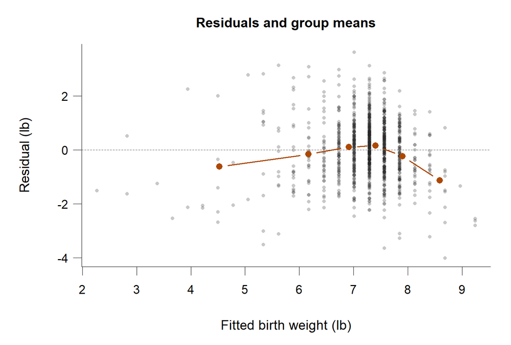

虛線為殘差 0；橘點是六個週數區間的平均殘差，連線僅引導讀圖。

- 兩端殘差偏負、中間偏正；早產端上下較寬。

births14；自製圖，橘色折線為各週數區間的平均殘差

## cut()：分組摘要殘差

```r
resid_by_weeks <- bw_fit |>
  mutate(weeks_group = cut(weeks,
    breaks = c(20, 32, 36, 38,
               40, 42, 46))) |>
  group_by(weeks_group) |>
  summarise(
    n = n(),
    mean_resid = mean(resid),
    sd_resid = sd(resid)
  )
resid_by_weeks
```

| 週數 | n | 平均殘差 | 殘差 SD |
| --- | --- | --- | --- |
| (20,32] | 28 | −0.62 | 1.88 |
| (32,36] | 96 | −0.16 | 1.30 |
| (36,38] | 227 | 0.11 | 1.02 |
| (38,40] | 485 | 0.16 | 0.97 |
| (40,42] | 133 | −0.24 | 0.96 |
| (42,46] | 31 | −1.13 | 1.27 |

- `(20,32]`：大於 20、小於或等於 32。單位：磅。

births14 實跑結果

## 殘差表的兩個訊號

- **非線性**
- 兩端平均殘差為負、中間為正。
- 直線在兩端**高估**、中間略低估；這份資料的平均趨勢有彎曲訊號。
- **變異不相等**
- 極早產區間殘差 SD 約 1.9 磅，足月約 1.0 磅。
- 早產端的殘差散布較大；不能給所有週數相同的誤差保證。
- 平均殘差看系統性高／低估，殘差 SD 看散布；分組表補充原圖，兩種訊號要分開描述。

births14 實跑結果；IMS 2e §24.6

## 限制研究對象，結果也會改變

```r
bw_term <- bw |>
  filter(weeks >= 37)
fit_term <- lm(weight ~ weeks,
               data = bw_term)
coef(fit_term)
summary(fit_term)$r.squared
sd(bw$weeks)
sd(bw_term$weeks)
```

| 對象 | n | 斜率 | R² |
| --- | --- | --- | --- |
| 全部出生 | 1,000 | 0.279 | 0.300 |
| 37 週以上 | 876 | 0.129 | 0.035 |

- 週數 SD：2.56 → 1.47 週。
- 同時改變**對象、x 範圍與趨勢區段**。這不等於找出 124 個錯誤資料點。

births14 本機 R 重算；斜率單位：磅／週

## 兩條線回答不同的問題

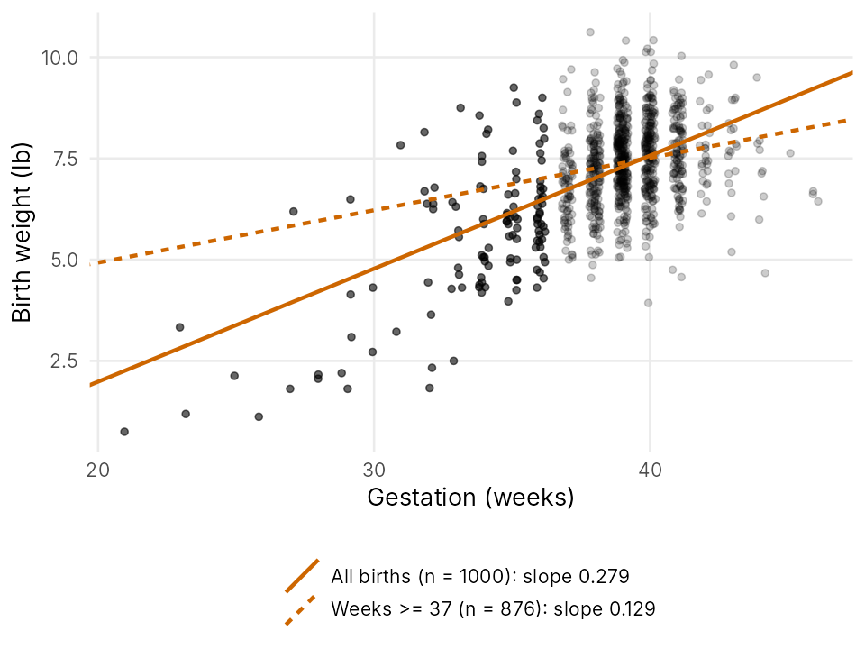

實線用全部出生紀錄，虛線只用 37 週以上紀錄；比較時也要看對象與範圍。

- 改為 37 週以上的新生兒，同時改變研究對象、週數範圍與 R² 的基準變異；兩個 R² 不能單獨判定模型優劣。

births14；自製圖；R² 基準對照 IMS 2e §7.2.5

## 練習 4｜差距告訴了你什麼？

```r
cor(bw$weeks, bw$weight)
cor(bw$weeks, bw$weight,
    method = "spearman")
```

| Pearson | Spearman |
| --- | --- |
| 0.548 | 0.384 |

- 同學說：「Spearman 比較小，所以改用它就解決模型問題。」請指出錯誤，並提出下一個檢查。
- 兩者衡量不同關聯；差距本身不能確定原因。
- 先看曲線、同分與極端點。Spearman 不會修好體重迴歸的彎曲或不等變異。

births14 實跑結果；本課程自編練習

## 交換 x 與 y

```r
coef(lm(weeks ~ weight,
        data = bw))
```

| 模型 | 斜率 |
| --- | --- |
| `weight ~ weeks` | 0.279 磅／週 |
| `weeks ~ weight` | 1.076 週／磅 |

- 1.076 ≠ 1／0.279。兩者的 r 都是 0.548。

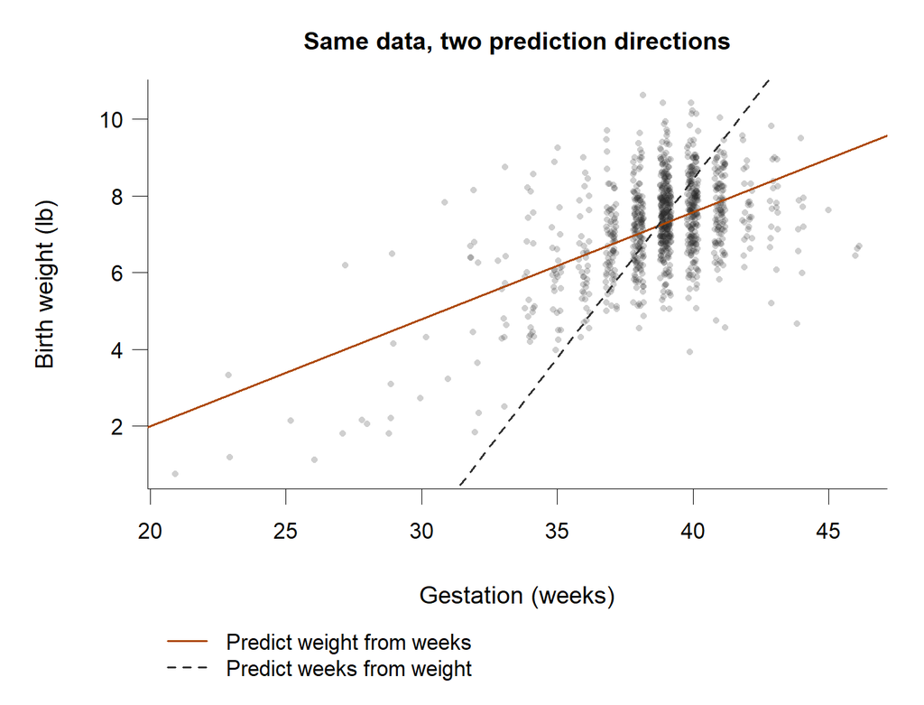

births14 實跑結果；自製圖

## predict() 與外插

```r
predict(fit,
  newdata = data.frame(
    weeks = c(39, 10)))
```

```
         1          2
 7.2914178 -0.8058193
```

| 週數 | 預測 | 判斷 |
| --- | --- | --- |
| 39 | 7.29 磅 | 在範圍內，仍需檢查模型 |
| 10 | −0.81 磅 | 外插（extrapolation） |

- 程式可執行，不表示適用：還要看範圍、研究對象、模型與你要預測的是誰。

[R predict.lm](https://stat.ethz.ch/R-manual/R-devel/library/stats/html/predict.lm.html)；births14 實跑結果；IMS 2e §7.2.4

## 練習 5｜程式正確，結論就正確？

```r
predict(fit,
  newdata = data.frame(weeks = 39))
# 約 7.29 磅
```

- 同學寫：「39 週的每位寶寶都會重 7.29 磅；在資料範圍內，所以預測一定準確。」
- 請改寫結論，交代兩項限制。
- 7.29 磅是**直線對平均體重的估計**，個別新生兒仍有殘差。
- 39 週沒有外插；殘差仍有彎曲與散布差異。
- **平均不是每個人；在範圍內也不保證預測準確。**

births14；本課程自編練習；IMS 2e §7.1.2、§24.6

## 保存輸出，Render

```r
dir.create("output",
           showWarnings = FALSE)
write_csv(resid_by_weeks,
  "output/week06_resid_by_weeks.csv")

p_resid <- ggplot(bw_fit,
  aes(x = fitted, y = resid)) +
  geom_point(alpha = 0.3)
ggsave("output/week06_residuals.png",
  p_resid, width = 6, height = 4,
  dpi = 150)
```

- 保存程式、圖與限制，結論才可追溯。先把表存成 `resid_by_weeks`、圖存成物件，再寫檔。
- 按 **Render**。逐行能跑、Render 卻失敗時，先查：
- 物件是否只在 Console 建立過
- `library()` 是否寫在第一塊
- 完整程式

[readr write_csv](https://readr.tidyverse.org/reference/write_delim.html)／[ggsave](https://ggplot2.tidyverse.org/reference/ggsave.html)；自編操作例

## 用三句話寫有範圍的結論

- 在 886 筆父母年齡完整的紀錄中，Pearson r = 0.69、Spearman = 0.73，呈正向關聯；遺漏紀錄是否相同仍未知。
- 全部 1,000 筆的線性摘要斜率為 0.28 磅／週，R² = 0.30；只看 37 週以上為 0.13 磅／週，兩者對象與範圍不同。
- 殘差有彎曲與散布差異，單一直線未完整描述各週數區段；這些觀察資料未證明因果，也未保證個別預測準確。

births14；自編結論範例；IMS 2e §24.6

## 這些結果，下一段如何解釋？

| 剛才得到的結果 | 要解釋的問題 |
| --- | --- |
| 交換兩個年齡，r 不變 | 為何 z 分數乘積有對稱性？ |
| 反向斜率不是原斜率的倒數 | 兩條最小平方線各在減少什麼誤差？ |
| 37 週以上 R² 降為 0.035 | 對象與範圍改變，能直接比模型優劣嗎？ |

- 數字已經算出來；接下來解釋它回答什麼、依賴什麼前提。

本課程自編整合；births14；IMS 2e §7.1–7.2

## Slido｜Part 1

Week 6 Part 1｜R 程式題 1–3，單選，每題 45 秒。

[**點此開啟 Slido 作答頁 ↗**](https://app.sli.do/event/np4ryBZ3zQwhyzSzh2Y6Vv) · 活動代碼 **4876800**

[figure not shown]

[Week 6 Slido 活動入口](https://app.sli.do/event/np4ryBZ3zQwhyzSzh2Y6Vv)；Week 6 Part 1，本課程自編題 1–3